# Zestaw 1

Amelia Madej

2023-10-16

# Zadanie 1

Definiuję zmienne o nazwach `pierwsza` i `druga`. Obie zmienne są wektorami składającymi się z ośmiu dowolnych obiektów będących cyframi. Do ich stworzenia używam funkcji `c()`.

```r
pierwsza <- c(1:8)
print(pierwsza)
```

```
## [1] 1 2 3 4 5 6 7 8
```

```r
druga <- c(9:16)
print(druga)
```

```
## [1]  9 10 11 12 13 14 15 16
```

- Wyznaczam zmienną `suma`, która jest wynikiem działania: `pierwsza + druga`, zmienną `różnica`, która jest wynikiem działania: `pierwsza - druga` oraz zmienną `wiecej`, która jest wynikiem działania: `pierwsza + 1`.

```r
suma <- pierwsza + druga
print(suma)
```

```
## [1] 10 12 14 16 18 20 22 24
```

```r
roznica <- pierwsza - druga
print(roznica)
```

```
## [1] -8 -8 -8 -8 -8 -8 -8 -8
```

```r
wiecej <- pierwsza + 1
print(wiecej)
```

```
## [1] 2 3 4 5 6 7 8 9
```

- Wyznaczam średnią arytmetyczną `mean()` oraz odchylenie standardowe `sd()`.

```r
pierwsza_srednia <- mean(pierwsza)
cat(pierwsza_srednia)
```

```
## 4.5
```

```r
druga_odchylenie_std <- sd(druga)
cat(druga_odchylenie_std)
```

```
## 2.44949
```

# Zadanie 2

Tworzę i uzupełniam ramkę danych o nazwie `osoby`, która składa się z siedmiu obserwacji i dwóch zmiennych: `wzrost` i `waga`.

```r
osoby <- data.frame("wzrost" = c(1.64, 1.74, 1.68, 1.77, 1.58, 1.49, 1.60),
                    "waga" = c(45, 56, 50, 70, 64, 48, 80))
```

- Wyświetlam strukturę obiektu.

```r
str(osoby)
```

```
## 'data.frame':    7 obs. of  2 variables:
##  $ wzrost: num  1.64 1.74 1.68 1.77 1.58 1.49 1.6
##  $ waga  : num  45 56 50 70 64 48 80
```

- Wyświetlam kilka pierwszych obiektów ze zbioru.

```r
head(osoby)
```

|  | wzrost | waga |
| --- | --- | --- |
| 1 | 1.64 | 45 |
| 2 | 1.74 | 56 |
| 3 | 1.68 | 50 |
| 4 | 1.77 | 70 |
| 5 | 1.58 | 64 |
| 6 | 1.49 | 48 |

- Wyświetlam kilka ostatnich obiektów ze zbioru.

```r
tail(osoby)
```

|  | wzrost | waga |
| --- | --- | --- |
| 2 | 1.74 | 56 |
| 3 | 1.68 | 50 |
| 4 | 1.77 | 70 |
| 5 | 1.58 | 64 |
| 6 | 1.49 | 48 |
| 7 | 1.60 | 80 |

- Wyświetlam wymiar ramki danych.

```r
dim(osoby)
```

```
## [1] 7 2
```

- Wyznaczam statystyki opisowe w obiekcie.

```r
summary(osoby)
```

```
##      wzrost           waga
##  Min.   :1.490   Min.   :45
##  1st Qu.:1.590   1st Qu.:49
##  Median :1.640   Median :56
##  Mean   :1.643   Mean   :59
##  3rd Qu.:1.710   3rd Qu.:67
##  Max.   :1.770   Max.   :80
```

# Zadanie 3

- Wykorzystując dane z *Zadanie 2* i funkcję `rownames()` nadaję imiona obiektom w ramce `osoby`.

```r
rownames(osoby) <- c("Alina", "Mateusz", "Amelia", "Dawid", "Weronika", "Justyna", "Filip")
```

- Tworzę obiekt `BMI`, który przechowuje informacje o wartościach BMI poszczególnych osób. Wykorzystuję funkcję `round()` do zaokrąglenia wartości BMI do dwóch miejsc po przecinku.

```r
BMI <- round(osoby$waga/(osoby$wzrost)^2, 2)
```

- Aktualizuję ramkę danych `osoby` dołączając do niej kolumnę z obliczonymi wartościami `BMI`. Wyświetlam zaaktualizowaną ramkę danych.

```r
osoby <- cbind(osoby, BMI)
osoby
```

|  | wzrost | waga | BMI |
| --- | --- | --- | --- |
| Alina | 1.64 | 45 | 16.73 |
| Mateusz | 1.74 | 56 | 18.50 |
| Amelia | 1.68 | 50 | 17.72 |
| Dawid | 1.77 | 70 | 22.34 |
| Weronika | 1.58 | 64 | 25.64 |
| Justyna | 1.49 | 48 | 21.62 |
| Filip | 1.60 | 80 | 31.25 |

- Wybieram i wyświetlam tylko te osoby, których BMI > 30.

```r
print(osoby[osoby$BMI > 30, ])
```

```
##       wzrost waga   BMI
## Filip    1.6   80 31.25
```

- Wyświetlam liczbę osób o BMI <= 25 wykorzystując funkcję `sum()`.

```r
print(sum(osoby$BMI <= 25))
```

```
## [1] 5
```

# Zadanie 4

Poniższe czynności wykonuję, aby poznać więcej informacji na temat zbiorów danych: `mtcars` i `Orange`.

- Sprawdzam podstawowe informacje na temat zbioru danych `mtcars` wykorzystując do tego funkcje `str()` i `help()`.

```r
str(mtcars)
```

```
## 'data.frame':    32 obs. of  11 variables:
##  $ mpg : num  21 21 22.8 21.4 18.7 18.1 14.3 24.4 22.8 19.2 ...
##  $ cyl : num  6 6 4 6 8 6 8 4 4 6 ...
##  $ disp: num  160 160 108 258 360 ...
##  $ hp  : num  110 110 93 110 175 105 245 62 95 123 ...
##  $ drat: num  3.9 3.9 3.85 3.08 3.15 2.76 3.21 3.69 3.92 3.92 ...
##  $ wt  : num  2.62 2.88 2.32 3.21 3.44 ...
##  $ qsec: num  16.5 17 18.6 19.4 17 ...
##  $ vs  : num  0 0 1 1 0 1 0 1 1 1 ...
##  $ am  : num  1 1 1 0 0 0 0 0 0 0 ...
##  $ gear: num  4 4 4 3 3 3 3 4 4 4 ...
##  $ carb: num  4 4 1 1 2 1 4 2 2 4 ...
```

```r
help(mtcars)
```

Jest to zbiór danych składający się z 32 obserwacji, zawierający informacje techniczne samochodów takie jak np. spalanie, waga, ilość koni mechanicznych itd.

- Sprawdzam podstawowe informacje na temat zbioru danych `Orange`.

```r
str(Orange)
```

```
## Classes 'nfnGroupedData', 'nfGroupedData', 'groupedData' and 'data.frame':   35 obs. of  3 variables:
##  $ Tree         : Ord.factor w/ 5 levels "3"<"1"<"5"<"2"<..: 2 2 2 2 2 2 2 4 4 4 ...
##  $ age          : num  118 484 664 1004 1231 ...
##  $ circumference: num  30 58 87 115 120 142 145 33 69 111 ...
##  - attr(*, "formula")=Class 'formula'  language circumference ~ age | Tree
##   .. ..- attr(*, ".Environment")=<environment: R_EmptyEnv>
##  - attr(*, "labels")=List of 2
##   ..$ x: chr "Time since December 31, 1968"
##   ..$ y: chr "Trunk circumference"
##  - attr(*, "units")=List of 2
##   ..$ x: chr "(days)"
##   ..$ y: chr "(mm)"
```

```r
help(Orange)
```

Jest to zbiór danych składający się z 35 obserwacji dotyczących wzrostu drzew pomarańczy. Zawiera on informacje o: drzewie, wieku i obwodzie pnia.

- Wyświetlam auta posiadające wyłącznie 6 cylindrów.

```r
mtcars[mtcars$cyl == 6, ]
```

|  | mpg | cyl | disp | hp | drat | wt | qsec | vs | am | gear | carb |
| --- | --- | --- | --- | --- | --- | --- | --- | --- | --- | --- | --- |
| Mazda RX4 | 21.0 | 6 | 160.0 | 110 | 3.90 | 2.620 | 16.46 | 0 | 1 | 4 | 4 |
| Mazda RX4 Wag | 21.0 | 6 | 160.0 | 110 | 3.90 | 2.875 | 17.02 | 0 | 1 | 4 | 4 |
| Hornet 4 Drive | 21.4 | 6 | 258.0 | 110 | 3.08 | 3.215 | 19.44 | 1 | 0 | 3 | 1 |
| Valiant | 18.1 | 6 | 225.0 | 105 | 2.76 | 3.460 | 20.22 | 1 | 0 | 3 | 1 |
| Merc 280 | 19.2 | 6 | 167.6 | 123 | 3.92 | 3.440 | 18.30 | 1 | 0 | 4 | 4 |
| Merc 280C | 17.8 | 6 | 167.6 | 123 | 3.92 | 3.440 | 18.90 | 1 | 0 | 4 | 4 |
| Ferrari Dino | 19.7 | 6 | 145.0 | 175 | 3.62 | 2.770 | 15.50 | 0 | 1 | 5 | 6 |

- Przeciętna liczba koni mechanicznych aut o spalaniu mniejszym niż 20.

```r
mean(mtcars$hp[mtcars$mpg < 20])
```

```
## [1] 191.9444
```

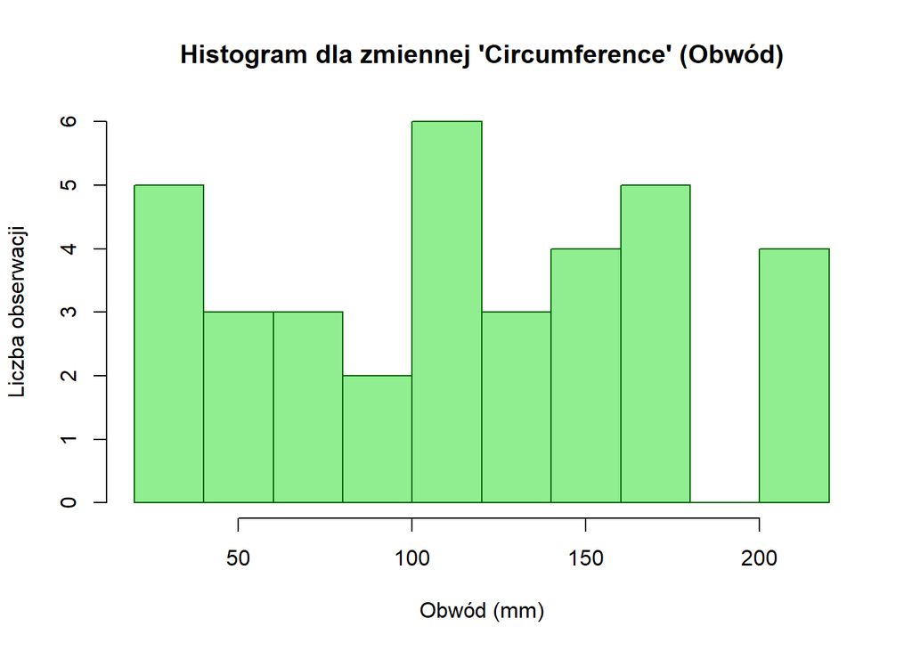

```r
hist(Orange$circumference,
     xlab = "Obwód (mm)",
     ylab = "Liczba obserwacji",
     main = "Histogram dla zmiennej 'Circumference' (Obwód)",
     col = "lightgreen",
     border = "darkgreen",
     breaks =10)
```

- Rysuję wykresy pudełkowe z wąsem dla zmiennych `mpg`, `hp` i `qsec` ze zbioru `mtcars`.

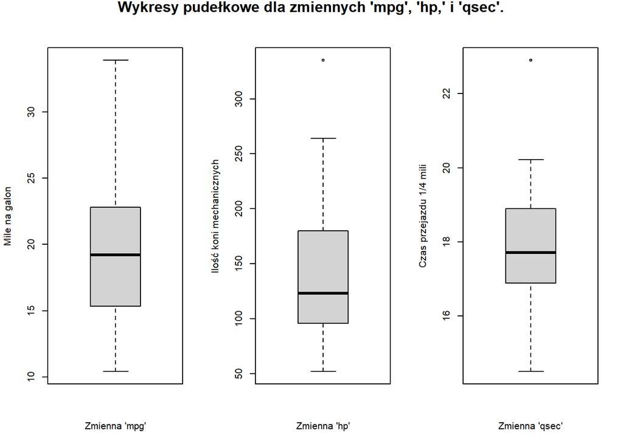

```r
# ustalam układ siatki na jeden wiersz i trzy kolumny
par(mfrow = c(1, 3))

# generuję wykresy
boxplot(mtcars$mpg,
        # podpisuję osie OX i OY
        xlab = "Zmienna 'mpg'",
        ylab = "Mile na galon"
        )
boxplot(mtcars$hp,
        # podpisuję osie OX i OY
        xlab = "Zmienna 'hp'",
        ylab = "Ilość koni mechanicznych"
        )
boxplot(mtcars$qsec,
        # podpisuję osie OX i OY
        xlab = "Zmienna 'qsec'",
        ylab = "Czas przejazdu 1/4 mili"
        )

# dodaję tytuł dla wykresów
title("Wykresy pudełkowe dla zmiennych 'mpg', 'hp,' i 'qsec'.", line = -1, outer = TRUE, cex.main = 1.5)
```

# Zadanie 5

- Instaluję pakiet `psych` wykorzystując funkcję `install.packages()` i wczytuję go do pamięci za pomocą funkcji `library()`.

**Uwaga.** Na początku ustawiam repozytorium CRAN jako źródło pakietów R do instalacji i aktualizacji.

```r
options(repos = c(CRAN = "https://cran.r-project.org"))
install.packages("psych")
library("psych")
```

- Wyświetlam statystyki opisowe dla danych `mtcars` wykorzystując funkcje `describe()` i `summary()`.

```r
describe(mtcars)
```

|  | vars | n | mean | sd | median | trimmed | mad | min | max | range | skew | kurtosis | se |
| --- | --- | --- | --- | --- | --- | --- | --- | --- | --- | --- | --- | --- | --- |
| mpg | 1 | 32 | 20.090625 | 6.0269481 | 19.200 | 19.6961538 | 5.4114900 | 10.400 | 33.900 | 23.500 | 0.6106550 | -0.37276603 | 1.06542396 |
| cyl | 2 | 32 | 6.187500 | 1.7859216 | 6.000 | 6.2307692 | 2.9652000 | 4.000 | 8.000 | 4.000 | -0.1746119 | -1.76211977 | 0.31570933 |
| disp | 3 | 32 | 230.721875 | 123.9386938 | 196.300 | 222.5230769 | 140.4763500 | 71.100 | 472.000 | 400.900 | 0.3816570 | -1.20721195 | 21.90947271 |
| hp | 4 | 32 | 146.687500 | 68.5628685 | 123.000 | 141.1923077 | 77.0952000 | 52.000 | 335.000 | 283.000 | 0.7260237 | -0.13555112 | 12.12031731 |
| drat | 5 | 32 | 3.596563 | 0.5346787 | 3.695 | 3.5792308 | 0.7042350 | 2.760 | 4.930 | 2.170 | 0.2659039 | -0.71470062 | 0.09451874 |
| wt | 6 | 32 | 3.217250 | 0.9784574 | 3.325 | 3.1526923 | 0.7672455 | 1.513 | 5.424 | 3.911 | 0.4231465 | -0.02271075 | 0.17296847 |
| qsec | 7 | 32 | 17.848750 | 1.7869432 | 17.710 | 17.8276923 | 1.4158830 | 14.500 | 22.900 | 8.400 | 0.3690453 | 0.33511422 | 0.31588992 |
| vs | 8 | 32 | 0.437500 | 0.5040161 | 0.000 | 0.4230769 | 0.0000000 | 0.000 | 1.000 | 1.000 | 0.2402577 | -2.00193762 | 0.08909831 |
| am | 9 | 32 | 0.406250 | 0.4989909 | 0.000 | 0.3846154 | 0.0000000 | 0.000 | 1.000 | 1.000 | 0.3640159 | -1.92474143 | 0.08820997 |
| gear | 10 | 32 | 3.687500 | 0.7378041 | 4.000 | 3.6153846 | 1.4826000 | 3.000 | 5.000 | 2.000 | 0.5288545 | -1.06975068 | 0.13042656 |

[output cut: 1 more lines]

```r
summary(mtcars)
```

```
##       mpg             cyl             disp             hp
##  Min.   :10.40   Min.   :4.000   Min.   : 71.1   Min.   : 52.0
##  1st Qu.:15.43   1st Qu.:4.000   1st Qu.:120.8   1st Qu.: 96.5
##  Median :19.20   Median :6.000   Median :196.3   Median :123.0
##  Mean   :20.09   Mean   :6.188   Mean   :230.7   Mean   :146.7
##  3rd Qu.:22.80   3rd Qu.:8.000   3rd Qu.:326.0   3rd Qu.:180.0
##  Max.   :33.90   Max.   :8.000   Max.   :472.0   Max.   :335.0
##       drat             wt             qsec             vs
##  Min.   :2.760   Min.   :1.513   Min.   :14.50   Min.   :0.0000
##  1st Qu.:3.080   1st Qu.:2.581   1st Qu.:16.89   1st Qu.:0.0000
##  Median :3.695   Median :3.325   Median :17.71   Median :0.0000
##  Mean   :3.597   Mean   :3.217   Mean   :17.85   Mean   :0.4375
##  3rd Qu.:3.920   3rd Qu.:3.610   3rd Qu.:18.90   3rd Qu.:1.0000
##  Max.   :4.930   Max.   :5.424   Max.   :22.90   Max.   :1.0000
##        am              gear            carb
##  Min.   :0.0000   Min.   :3.000   Min.   :1.000
##  1st Qu.:0.0000   1st Qu.:3.000   1st Qu.:2.000
##  Median :0.0000   Median :4.000   Median :2.000
##  Mean   :0.4062   Mean   :3.688   Mean   :2.812
##  3rd Qu.:1.0000   3rd Qu.:4.000   3rd Qu.:4.000
##  Max.   :1.0000   Max.   :5.000   Max.   :8.000
```

- Funkcja `summary()` generuje podstwowe statystyki opisowe dla obiektu danych. Podsumowanie zawiera informacje takie jak: min, max, średnią, kwartyle oraz liczbę brakujących wartości.
- Funkcja`describe()` jest dużo bardziej szczegółowa i wyświetla bardziej szczegółowe statystyki opisowe, w tym miary tendencji centralnej, miary rozproszczenia, kwartyle, skośność, kurtozę itp.

Propozycja wykorzystania funkcji describeBy():

- Wykorzystanie describeBy() do analizy zużycia paliwa (`mpg`) według liczby cylindrów (`cyl`).

```r
describeBy(mtcars$mpg, mtcars$cyl)
```

```
##
##  Descriptive statistics by group
## group: 4
##    vars  n  mean   sd median trimmed  mad  min  max range skew kurtosis   se
## X1    1 11 26.66 4.51     26   26.44 6.52 21.4 33.9  12.5 0.26    -1.65 1.36
## ------------------------------------------------------------
## group: 6
##    vars n  mean   sd median trimmed  mad  min  max range  skew kurtosis   se
## X1    1 7 19.74 1.45   19.7   19.74 1.93 17.8 21.4   3.6 -0.16    -1.91 0.55
## ------------------------------------------------------------
## group: 8
##    vars  n mean   sd median trimmed  mad  min  max range  skew kurtosis   se
## X1    1 14 15.1 2.56   15.2   15.15 1.56 10.4 19.2   8.8 -0.36    -0.57 0.68
```

# Zadanie 6

- Wykorzystuję funkcję `sample()` do wygenerowania 20 wyników rzutu kostką do gry. Przypisuję je do zmiennej `proba`. Następnie liczę średnią i odchylenie standardowe dla wartości tej zmiennej.

```r
proba <- sample(x = 1:6, size = 20, replace = TRUE)
print(proba)
```

```
##  [1] 3 5 2 6 4 4 4 1 4 2 2 4 5 4 5 6 6 5 6 6
```

```r
mean(proba)
```

```
## [1] 4.2
```

```r
sd(proba)
```

```
## [1] 1.542384
```

- Generuję 100 wyników rzutu monetą i przypisuję te wartości do zmiennej `rzut`.

**Uwaga!** Przyjęte oznaczenia: `1` - orzeł, `0` - reszka.

```r
rzut <- sample(x = 0:1, size = 100, replace = TRUE)
```

- Wyliczam i wyświetlam liczbę wyrzuconych orłów wykorzystując funkcję `sum()`.

```r
liczba_orlow <- sum(rzut)
cat(liczba_orlow)
```

```
## 53
```

- Losuje bez zwracania 10 liczb ze zbioru l. naturalnych od 0 do 100. Wyświetlam je.

```r
bez_zwracania <- sample(x = 0:100, size = 10, replace = FALSE)
cat(bez_zwracania)
```

```
## 58 42 78 62 38 25 13 67 93 18
```

- Wykorzystuję funkcję `rnorm()` i stosuję ją na wymyślonym przykładzie tj. generuję i wyświetlam 7 losowych pomiarów temperatury maksymalnej (w stopniach Celsjusza) w sierpniu dla Krakowa.

```r
dane_temperatury <- rnorm(n = 7, mean = 24, sd = 3)

# zaokrąglam wyniki do części dziesiętych
round(dane_temperatury, 1)
```

```
## [1] 24.9 20.5 25.6 25.1 21.2 26.4 19.5
```

# Zadanie 7

Tworzę zestaw danych `lista` wg instrukcji z treści zadania.

```r
lista <- list(palenie = c(F,T,T,F,F,T,F),
              cyfry = 0:9,
              macierz = matrix(sample(x = 1:5, size = 16, replace = T), nrow = 4, ncol = 4),
              tekst = c("Litwo", "ojczyzno", "moja", "ty", "jestes", "jak", "zdrowie"))


print(lista)
```

```
## $palenie
## [1] FALSE  TRUE  TRUE FALSE FALSE  TRUE FALSE
##
## $cyfry
##  [1] 0 1 2 3 4 5 6 7 8 9
##
## $macierz
##      [,1] [,2] [,3] [,4]
## [1,]    3    1    4    2
## [2,]    5    1    2    4
## [3,]    4    5    4    2
## [4,]    3    4    3    3
##
## $tekst
## [1] "Litwo"    "ojczyzno" "moja"     "ty"       "jestes"   "jak"      "zdrowie"
```

- Odwołuję się do obiektu `tekst` na trzy sposoby.

```r
lista[[4]]
```

```
## [1] "Litwo"    "ojczyzno" "moja"     "ty"       "jestes"   "jak"      "zdrowie"
```

```r
lista[["tekst"]]
```

```
## [1] "Litwo"    "ojczyzno" "moja"     "ty"       "jestes"   "jak"      "zdrowie"
```

```r
lista$tekst
```

```
## [1] "Litwo"    "ojczyzno" "moja"     "ty"       "jestes"   "jak"      "zdrowie"
```

- Odwołuję się do trzeciego elementu wektora `cyfry` na trzy sposoby.

```r
lista[[2]][3]
```

```
## [1] 2
```

```r
lista[["cyfry"]][3]
```

```
## [1] 2
```

```r
lista$cyfry[3]
```

```
## [1] 2
```

- Odwołuję się do trzeciej kolumny obiektu `macierz` na trzy sposoby.

```r
lista[[3]][, 3]
```

```
## [1] 4 2 4 3
```

```r
lista[["macierz"]][, 3]
```

```
## [1] 4 2 4 3
```

```r
lista$macierz[, 3]
```

```
## [1] 4 2 4 3
```

# Zadanie 8

- Definiuję zmienne `wiek` i `waga`, które opisują osoby o danej wadze i danym wieku.

```r
wiek <- c(50, 17, 39, 27, 90)
waga <- c(80, 75, 92, 105, 60)
```

- Tworzę i wyświetlam ramkę danych `pacjenci`.

```r
pacjenci <- data.frame(wiek, waga)
pacjenci
```

| wiek | waga |
| --- | --- |
| 50 | 80 |
| 17 | 75 |
| 39 | 92 |
| 27 | 105 |
| 90 | 60 |

```r
pacjenci[pacjenci$wiek > 18 | pacjenci$waga <90, ]
```

|  | wiek | waga |
| --- | --- | --- |
| 1 | 50 | 80 |
| 2 | 17 | 75 |
| 3 | 39 | 92 |
| 4 | 27 | 105 |
| 5 | 90 | 60 |

# Zadanie 9

Instaluję pakiet `nycflights13` i wczytuję go do pamięci. W tym celu wykorzystuję funkcje `install.packages()` oraz `library()`.

```r
install.packages("nycflights13")
library(nycflights13)
```

- Buduję model regresji na podstawie kodu z zadania w oparciu o zainstalowany pakiet `nycflights13`.

```r
flight_lm <- lm(arr_delay ~ dep_delay + month + carrier, data = flights)
flight_lm
```

```
##
## Call:
## lm(formula = arr_delay ~ dep_delay + month + carrier, data = flights)
##
## Coefficients:
## (Intercept)    dep_delay        month    carrierAA    carrierAS    carrierB6
##    -9.51708      1.01895      0.02202      1.00688     -6.49670      5.61792
##   carrierDL    carrierEV    carrierF9    carrierFL    carrierHA    carrierMQ
##     1.61750      4.95322     10.70873     10.54141     -2.52974      9.50579
##   carrierOO    carrierUA    carrierUS    carrierVX    carrierWN    carrierYV
##     8.43130      0.68573      7.68632     -1.86928      1.02319      5.66450
```

- Szukam liczby różnych pozycji znajdujących się na tej liście.

```r
length(unique(flight_lm))
```

```
## [1] 14
```

- Szukam jak nazywają sią elementy listy.

```r
unique(names(flight_lm))
```

```
##  [1] "coefficients"  "residuals"     "effects"       "rank"
##  [5] "fitted.values" "assign"        "qr"            "df.residual"
##  [9] "na.action"     "contrasts"     "xlevels"       "call"
## [13] "terms"         "model"
```

- Wyświetlam współczynniki tego modelu.

```r
coef(flight_lm)
```

```
## (Intercept)   dep_delay       month   carrierAA   carrierAS   carrierB6
## -9.51708354  1.01895142  0.02201799  1.00688211 -6.49669534  5.61792131
##   carrierDL   carrierEV   carrierF9   carrierFL   carrierHA   carrierMQ
##  1.61750225  4.95322249 10.70873197 10.54141321 -2.52973865  9.50579130
##   carrierOO   carrierUA   carrierUS   carrierVX   carrierWN   carrierYV
##  8.43129663  0.68573297  7.68631797 -1.86928468  1.02318926  5.66450384
```

# Zadanie 10

- Wyswietlam macierz `VADeaths`.

```r
VADeaths
```

```
##       Rural Male Rural Female Urban Male Urban Female
## 50-54       11.7          8.7       15.4          8.4
## 55-59       18.1         11.7       24.3         13.6
## 60-64       26.9         20.3       37.0         19.3
## 65-69       41.0         30.9       54.6         35.1
## 70-74       66.0         54.3       71.1         50.0
```

- Wyświetlam nazwy wierszy i kolumn oraz strukturę macierzy.

```r
dimnames(VADeaths)
```

```
## [[1]]
## [1] "50-54" "55-59" "60-64" "65-69" "70-74"
##
## [[2]]
## [1] "Rural Male"   "Rural Female" "Urban Male"   "Urban Female"
```

```r
str(VADeaths)
```

```
##  num [1:5, 1:4] 11.7 18.1 26.9 41 66 8.7 11.7 20.3 30.9 54.3 ...
##  - attr(*, "dimnames")=List of 2
##   ..$ : chr [1:5] "50-54" "55-59" "60-64" "65-69" ...
##   ..$ : chr [1:4] "Rural Male" "Rural Female" "Urban Male" "Urban Female"
```

- Zmieniam nazwy kolumn na j. polski.

```r
colnames(VADeaths) <- c("Wiejscy Mezczyzni", "Wiejskie Kobiety", "Miejscy Mezczyzni", "Miejskie Kobiety")
colnames(VADeaths)
```

```
## [1] "Wiejscy Mezczyzni" "Wiejskie Kobiety"  "Miejscy Mezczyzni"
## [4] "Miejskie Kobiety"
```

Dzielę macierz na dwie podmacierze.

- Macierz tylko dla mężczyzn:

```r
VADeaths_mezczyzni <- VADeaths[ , c("Wiejscy Mezczyzni", "Miejscy Mezczyzni")]
VADeaths_mezczyzni
```

```
##       Wiejscy Mezczyzni Miejscy Mezczyzni
## 50-54              11.7              15.4
## 55-59              18.1              24.3
## 60-64              26.9              37.0
## 65-69              41.0              54.6
## 70-74              66.0              71.1
```

- Macierz tylko dla kobiet:

```r
VADeaths_kobiety <- VADeaths[ , c("Wiejskie Kobiety", "Miejskie Kobiety")]
VADeaths_kobiety
```

```
##       Wiejskie Kobiety Miejskie Kobiety
## 50-54              8.7              8.4
## 55-59             11.7             13.6
## 60-64             20.3             19.3
## 65-69             30.9             35.1
## 70-74             54.3             50.0
```

- Liczę średnie dla każdej kolumny i dodaję je jako ostatni wiersz w macierzy.

```r
srednie_kolumn <- colMeans(VADeaths)
rbind(VADeaths, srednie_kolumn)
```

```
##                Wiejscy Mezczyzni Wiejskie Kobiety Miejscy Mezczyzni
## 50-54                      11.70             8.70             15.40
## 55-59                      18.10            11.70             24.30
## 60-64                      26.90            20.30             37.00
## 65-69                      41.00            30.90             54.60
## 70-74                      66.00            54.30             71.10
## srednie_kolumn             32.74            25.18             40.48
##                Miejskie Kobiety
## 50-54                      8.40
## 55-59                     13.60
## 60-64                     19.30
## 65-69                     35.10
## 70-74                     50.00
## srednie_kolumn            25.28
```

- Liczę średnie dla każdego wiersza i dodaję je jako ostatnią kolumnę macierzy.

```r
srednie_wierszy <- rowMeans(VADeaths)
cbind(VADeaths, srednie_wierszy)
```

```
##       Wiejscy Mezczyzni Wiejskie Kobiety Miejscy Mezczyzni Miejskie Kobiety
## 50-54              11.7              8.7              15.4              8.4
## 55-59              18.1             11.7              24.3             13.6
## 60-64              26.9             20.3              37.0             19.3
## 65-69              41.0             30.9              54.6             35.1
## 70-74              66.0             54.3              71.1             50.0
##       srednie_wierszy
## 50-54          11.050
## 55-59          16.925
## 60-64          25.875
## 65-69          40.400
## 70-74          60.350
```

# Zadanie 11

Tworzę dowoloną przykładową zmienną `liczba` za pomocą funkcji `sample()`.

```r
liczba <- sample(x = 1:100, size = 1)
```

- Używam instrukcji `if-else` do sprawdzenia podzielności zmiennej `liczba` przez 4.

```r
if (liczba %% 4 == 0){
  cat("Liczba", liczba, "jest podzielna przez 4.\n")
} else {
  cat("Liczba", liczba, "nie jest podzielna przez 4.\n")
}
```

```
## Liczba 10 nie jest podzielna przez 4.
```

- Używam funkcji `ifelse` do sprawdzenia podzielności zmiennej `liczba` przez 4. Wykorzystuję funkcję `paste` do wyświetlenia wyniku.

```r
ifelse(liczba %% 4 == 0, paste(liczba, "dzieli się przez 4."), paste(liczba,"nie dzieli się przez 4."))
```

```
## [1] "10 nie dzieli się przez 4."
```

# Zadanie 12

Tworzę zmienną `ksiazki`, która mówi o tym, ile dana osoba przeczytała książek w ostatnim kwartale.

```r
ksiazki <- sample(0:4, size = 25, replace = TRUE)
ksiazki
```

```
##  [1] 1 0 1 3 3 4 3 2 1 4 0 3 0 3 2 0 0 4 3 3 3 3 1 3 0
```

- Liczę średnią liczbę przeczytanych książek.

```r
mean(ksiazki)
```

```
## [1] 2
```

- Szukam liczby osób, które przeczytały co najmniej trzy książki.

```r
sum(ksiazki >= 3)
```

```
## [1] 13
```

- Szukam liczby osób, które nie przeczytały żadnej książki.

```r
sum(ksiazki == 0)
```

```
## [1] 6
```

- Tworzę zmienną `ksiazki2`, która będzie mówiła o tym czy ktoś czyta książki (warunek to min. jedna przeczytana książka). Wykorzystuję do tego pętlę `for`. Następnie, za pomocą funkcji `append` dołączam do zmiennej `ksiazki2` informacje o tym czy ktoś czyta.

```r
ksiazki2 <- c()

for(i in ksiazki){
  if(i > 0){
    ksiazki2 <- append(ksiazki2, "Czyta", length(ksiazki2))
  }
  else{
    ksiazki2 <- append(ksiazki2, "Nie czyta", length(ksiazki2))
  }
}

ksiazki2
```

```
##  [1] "Czyta"     "Nie czyta" "Czyta"     "Czyta"     "Czyta"     "Czyta"
##  [7] "Czyta"     "Czyta"     "Czyta"     "Czyta"     "Nie czyta" "Czyta"
## [13] "Nie czyta" "Czyta"     "Czyta"     "Nie czyta" "Nie czyta" "Czyta"
## [19] "Czyta"     "Czyta"     "Czyta"     "Czyta"     "Czyta"     "Czyta"
## [25] "Nie czyta"
```

- Dla testów losuję `miesiac` i `rok`.

**Uwaga!** Specjalnie dopuszczam opcje “0” dla miesiąca, aby sprawdzić poprawność jednego z warunków.

```r
miesiac <- sample(0:12, 1)
rok <- sample(0:3000, 1)
```

- Tworzę instrukcje warunkową, która mając datę (miesiąc i rok), odpowie na pytanie o liczbę dni w tym miesiącu.

```r
if(miesiac %in% 1:12){

  # Tworzę wektor z ilością dni w miesiącach
  dni_w_miesiacach <- c(31, 28, 31, 30, 31, 30, 31, 31, 30, 31, 30, 31)

  # Sprawdzam czy miesiąc to luty oraz czy dany rok jest przestępny
  if(miesiac == 2 && (rok %% 4 == 0 && (rok%% 100 != 0 || rok %% 400 == 0))){
    # Jeśli warunek jest prawdziwy to dodaję jeden dzień do lutego
    cat("Liczba dni w miesiacu", miesiac, "w roku", rok, "to", dni_w_miesiacach[miesiac]+1)
  }
  else {

    cat("Liczba dni w miesiacu", miesiac, "w roku", rok, "to", dni_w_miesiacach[miesiac])

  }
}
```

```
## Liczba dni w miesiacu 4 w roku 2618 to 30
```

# Zadanie 13

Tworzę funkcję `zamiana_temp`, która zamienia temperaturę w Celsjuszach na temperaturę w Kelwinach i Fahrenheitah.

- Tworzę zmienne `temperatura_K` i `temperatura_F`, które będą przechowywać odpowiednio informację o ilości stopni w przeliczeniu na Kelwiny i Fahrenheity. Następnie tworzę ramkę danych `wyniki`, która będzie podsumowywała uzyskane wartości.

```r
zmiana_temp <- function(temperatura_C){

  temperatura_K <- temperatura_C + 273.15
  temperatura_F <- temperatura_C * 1.8 + 32

  wyniki <- data.frame(temperatura_C, temperatura_K, temperatura_F)

  return(wyniki)
}
```

- Definiuję zmienną `temperatura` dla testów, przypisuję jej wartość `0`, aby w łatwy sposób potwierdzić poprawność działania funkcji.

```r
temperatura_C <- 0
zmiana_temp(temperatura_C)
```

| temperatura_C | temperatura_K | temperatura_F |
| --- | --- | --- |
| 0 | 273.15 | 32 |

# Zadanie 14

Tworzę funkcję `pole_trojkata` liczącą pole trojkąta na podstawie wzoru Herona:

$$P = \sqrt{p(p-a)(p-b)(p-c)}$$
gdzie:

$$p = {(a + b + c)/2}$$

```r
pole_trojkata <- function(a, b, c){

  # Sprawdzam czy długości boków spełniają warunek powstania trójkąta
  if(a + b > c && a + c > b && b + c > a){

    # Obliczam połowę obwodu trójkąta
    p <- (a + b + c)/2
    # Obliczam pole trójkąta wykorzystując wzór Herona
    pole <- sqrt(p*(p - a)*(p - b)*(p - c))


    # Wyświetlam wynik
    cat("Pole trójkąt o bokach:", a, b, c, "wynosi", pole, "\n")
  }
  else{
    cat("Nie można obliczyć pola! Podane długości boków nie tworzą trójkąta.")
  }
}
```

- Testuję funkcję `pole_trojkata`:

```r
# Testowe liczby
a <- 3
b <- 4
c <- 5

# Test funkcji
pole_trojkata(a, b, c)
```

```
## Pole trójkąt o bokach: 3 4 5 wynosi 6
```

# Zadanie 15

Tworzę funkcję `rodzaj_trojkata`, która na podstawie długości boków trójkąta odpowiada na pytanie o to, czy trójkąt jest ostrokątny, prostokątny lub rozwartokątny.

```r
rodzaj_trojkata <- function(a, b, c){

  # Sprawdzam czy podane długości tworzą trójkąt
  if((a + b > c) && (a + c > b) && (b + c > a)){

    # Obliczam kwadraty długości boków
    a2 <- a^2
    b2 <- b^2
    c2 <- c^2

    # Porównuję kwadraty długości boków i wyświetlam odpowiednią informację
    if((a2 + b2 > c2) && (a2 + c2 > b2) && (b2 + c2 > a2)){
      cat("Trojkat jest ostrokatny.\n")
    }
    else if ((a2 + b2 == c2) || (a2 + c2 == b2) || (b2 + c2 == a2)){
      cat("Trojkat jest prostokatny.\n")
    }
    else{
      cat("Trojkat jest rozwartokatny.\n")
    }
  }
  else{
    cat("Podane dlugosci bokow nie tworza trojkata!\n")
  }
}
```

- Testuję działanie funkcji:

```r
a <- 3
b <- 4
c <- 5
rodzaj_trojkata(a,b,c)
```

```
## Trojkat jest prostokatny.
```

# Zadanie 16

Tworzę ramkę danych `osoby` za pomocą funkcji `sample()` i `rnorm()`.

```r
wzrost <- round(rnorm(100, 175, 10),0)
waga   <- round(wzrost - 105 + rnorm(1,0,5))
wiek   <- sample(20:60, 100, replace = TRUE)
dzieci <- rpois(100, lambda = 1)

osoby  <- data.frame(wzrost = wzrost, waga = waga,
                     wiek = wiek, dzieci = dzieci)

head(osoby)
```

|  | wzrost | waga | wiek | dzieci |
| --- | --- | --- | --- | --- |
| 1 | 174 | 70 | 40 | 1 |
| 2 | 155 | 51 | 44 | 0 |
| 3 | 181 | 77 | 43 | 0 |
| 4 | 186 | 82 | 46 | 2 |
| 5 | 177 | 73 | 39 | 1 |
| 6 | 180 | 76 | 51 | 2 |

Dołączam do zestawu danych zmienną `BMI` oraz zmienną `plec`, gdzie pierwsza połowa danych to kobiety, a druga to mężczyzni. Wykorzystuję do tego funkcję `rep()`.

```r
osoby$BMI <- round(osoby$waga/(osoby$wzrost/100)^2, 2)
osoby$plec <- rep(c("K", "M"), each = 50)
head(osoby)
```

|  | wzrost | waga | wiek | dzieci | BMI | plec |
| --- | --- | --- | --- | --- | --- | --- |
| 1 | 174 | 70 | 40 | 1 | 23.12 | K |
| 2 | 155 | 51 | 44 | 0 | 21.23 | K |
| 3 | 181 | 77 | 43 | 0 | 23.50 | K |
| 4 | 186 | 82 | 46 | 2 | 23.70 | K |
| 5 | 177 | 73 | 39 | 1 | 23.30 | K |
| 6 | 180 | 76 | 51 | 2 | 23.46 | K |

- Z wykorzystaniem funkcji: `str()`, `head()`, `tail()`, `dim()` oraz `summary()` przyglądam się uzyskanemu zestawowi danych.

```r
str(osoby)
```

```
## 'data.frame':    100 obs. of  6 variables:
##  $ wzrost: num  174 155 181 186 177 180 183 164 171 170 ...
##  $ waga  : num  70 51 77 82 73 76 79 60 67 66 ...
##  $ wiek  : int  40 44 43 46 39 51 43 46 37 44 ...
##  $ dzieci: int  1 0 0 2 1 2 2 0 3 1 ...
##  $ BMI   : num  23.1 21.2 23.5 23.7 23.3 ...
##  $ plec  : chr  "K" "K" "K" "K" ...
```

```r
head(osoby)
```

|  | wzrost | waga | wiek | dzieci | BMI | plec |
| --- | --- | --- | --- | --- | --- | --- |
| 1 | 174 | 70 | 40 | 1 | 23.12 | K |
| 2 | 155 | 51 | 44 | 0 | 21.23 | K |
| 3 | 181 | 77 | 43 | 0 | 23.50 | K |
| 4 | 186 | 82 | 46 | 2 | 23.70 | K |
| 5 | 177 | 73 | 39 | 1 | 23.30 | K |
| 6 | 180 | 76 | 51 | 2 | 23.46 | K |

```r
tail(osoby)
```

|  | wzrost | waga | wiek | dzieci | BMI | plec |
| --- | --- | --- | --- | --- | --- | --- |
| 95 | 188 | 84 | 32 | 4 | 23.77 | M |
| 96 | 178 | 74 | 42 | 1 | 23.36 | M |
| 97 | 167 | 63 | 59 | 0 | 22.59 | M |
| 98 | 178 | 74 | 56 | 1 | 23.36 | M |
| 99 | 159 | 55 | 29 | 2 | 21.76 | M |
| 100 | 150 | 46 | 57 | 0 | 20.44 | M |

```r
dim(osoby)
```

```
## [1] 100   6
```

```r
summary(osoby)
```

```
##      wzrost           waga            wiek           dzieci          BMI
##  Min.   :150.0   Min.   :46.00   Min.   :21.00   Min.   :0.00   Min.   :20.44
##  1st Qu.:168.8   1st Qu.:64.75   1st Qu.:32.00   1st Qu.:0.00   1st Qu.:22.74
##  Median :175.5   Median :71.50   Median :43.00   Median :1.00   Median :23.21
##  Mean   :175.5   Mean   :71.49   Mean   :41.68   Mean   :1.14   Mean   :23.06
##  3rd Qu.:182.2   3rd Qu.:78.25   3rd Qu.:51.00   3rd Qu.:2.00   3rd Qu.:23.56
##  Max.   :198.0   Max.   :94.00   Max.   :60.00   Max.   :5.00   Max.   :23.98
##      plec
##  Length:100
##  Class :character
##  Mode  :character
##
##
##
```

- Wyświetlam liczbę osób ze zbioru danych posiadających min. dwójkę dzieci. Wykorzystuję do tego funkcję `sum()` i operacje logiczne.

```r
sum(osoby$dzieci >= 2)
```

```
## [1] 31
```

- Wyodrębniam ze zbioru danych osoby, które posiadają wzrost min. 185 cm.

```r
osoby[osoby$wzrost >= 185, ]
```

|  | wzrost | waga | wiek | dzieci | BMI | plec |
| --- | --- | --- | --- | --- | --- | --- |
| 4 | 186 | 82 | 46 | 2 | 23.70 | K |
| 12 | 191 | 87 | 58 | 1 | 23.85 | K |
| 20 | 186 | 82 | 23 | 0 | 23.70 | K |
| 21 | 192 | 88 | 47 | 2 | 23.87 | K |
| 23 | 198 | 94 | 40 | 1 | 23.98 | K |
| 25 | 192 | 88 | 32 | 1 | 23.87 | K |
| 29 | 197 | 93 | 42 | 1 | 23.96 | K |
| 33 | 189 | 85 | 25 | 3 | 23.80 | K |
| 39 | 188 | 84 | 48 | 1 | 23.77 | K |
| 49 | 194 | 90 | 60 | 0 | 23.91 | K |

[output cut: 10 more lines]

- Obliczam średnią wzrostu w całej grupie i sprawdzam kto jest przeciętnie wyższy: kobiety czy mężczyźni? Do odpowiedzi na to pytanie wykorzystuję funkcję `describeBy()`.

```r
# Średnia wzrostu całej grupy
mean(osoby$wzrost)
```

```
## [1] 175.49
```

```r
# Instalacja i wczytanie do pamięci pakietu 'psych'
install.packages("psych")
library(psych)
```

```r
# Obliczam statystyki opisowe dla zmiennej 'wzrost' w zależności od zmiennej 'plec'
wyniki_opisowe <- describeBy(osoby$wzrost, osoby$plec)
print(wyniki_opisowe)
```

```
##
##  Descriptive statistics by group
## group: K
##    vars  n   mean    sd median trimmed mad min max range skew kurtosis   se
## X1    1 50 175.62 10.76    175  175.55 8.9 155 198    43 0.14    -0.57 1.52
## ------------------------------------------------------------
## group: M
##    vars  n   mean   sd median trimmed   mad min max range  skew kurtosis   se
## X1    1 50 175.36 9.67    177  175.52 10.38 150 197    47 -0.19     -0.3 1.37
```

```r
# Obliczam średni wzrost kobiet
srednia_kobiety <- wyniki_opisowe$K$mean
cat(srednia_kobiety)
```

```
## 175.62
```

```r
# Obliczam średni wzrost mężczyzn
srednia_mezczyzni <- wyniki_opisowe$M$mean
cat(srednia_mezczyzni)
```

```
## 175.36
```

```r
srednia_kobiety > srednia_mezczyzni
```

```
## [1] TRUE
```

- Wyświetlam tylko te osoby, których BMI > 30.

```r
osoby[osoby$BMI > 30, ]
```

| wzrost | waga | wiek | dzieci | BMI | plec |
| --- | --- | --- | --- | --- | --- |

- Podaję ile spośród nich to kobiety.

```r
sum(osoby[(osoby$plec == "K") & (osoby$BMI > 30)])
```

```
## [1] 0
```

- Podaję ile spośród nich to mężczyźni.

```r
sum(osoby[(osoby$plec == "M") & (osoby$BMI > 30)])
```

```
## [1] 0
```

- Dołączam do zestawu danych zmienna `wzrost2`, która przyjmuje trzy wartości: `niski`o ile wzrost < 165, `sredni`, o ile wzrost jest między 165 i 185 oraz `wysoki`, gdy wzrost >=185.

```r
wzrost2 <- wzrost
wzrost2[wzrost2 >= 185] <- "wysoki"
wzrost2[wzrost2 < 185 & wzrost2 >= 165] <- "sredni"
wzrost2[wzrost2 < 165] <- "niski"
wzrost2
```

```
##   [1] "sredni" "niski"  "sredni" "wysoki" "sredni" "sredni" "sredni" "niski"
##   [9] "sredni" "sredni" "sredni" "wysoki" "sredni" "sredni" "sredni" "niski"
##  [17] "sredni" "sredni" "sredni" "wysoki" "wysoki" "sredni" "wysoki" "sredni"
##  [25] "wysoki" "sredni" "sredni" "sredni" "wysoki" "sredni" "niski"  "sredni"
##  [33] "wysoki" "sredni" "niski"  "sredni" "sredni" "niski"  "wysoki" "niski"
##  [41] "sredni" "sredni" "niski"  "sredni" "sredni" "sredni" "sredni" "sredni"
##  [49] "wysoki" "wysoki" "sredni" "niski"  "sredni" "sredni" "sredni" "sredni"
##  [57] "sredni" "niski"  "sredni" "sredni" "sredni" "sredni" "sredni" "sredni"
##  [65] "sredni" "wysoki" "sredni" "wysoki" "sredni" "niski"  "sredni" "wysoki"
##  [73] "sredni" "wysoki" "sredni" "sredni" "wysoki" "sredni" "niski"  "sredni"
##  [81] "wysoki" "wysoki" "wysoki" "sredni" "sredni" "sredni" "sredni" "sredni"
##  [89] "niski"  "sredni" "sredni" "sredni" "sredni" "sredni" "wysoki" "sredni"
##  [97] "sredni" "sredni" "niski"  "niski"
```

```r
osoby$wzrost2 <- wzrost2
head(osoby)
```

|  | wzrost | waga | wiek | dzieci | BMI | plec | wzrost2 |
| --- | --- | --- | --- | --- | --- | --- | --- |
| 1 | 174 | 70 | 40 | 1 | 23.12 | K | sredni |
| 2 | 155 | 51 | 44 | 0 | 21.23 | K | niski |
| 3 | 181 | 77 | 43 | 0 | 23.50 | K | sredni |
| 4 | 186 | 82 | 46 | 2 | 23.70 | K | wysoki |
| 5 | 177 | 73 | 39 | 1 | 23.30 | K | sredni |
| 6 | 180 | 76 | 51 | 2 | 23.46 | K | sredni |

Korzystam z funkcji `summary()` dla zmiennej `wzrost2`. Jednak, dopiero po zmianie typu zmiennej na `factor` jestem w stanie określić, ile osób jest wysokich.

```r
summary(wzrost2)
```

```
##    Length     Class      Mode
##       100 character character
```

```r
class(wzrost2)
```

```
## [1] "character"
```

```r
wzrost2 <- factor(wzrost2)
summary(wzrost2)
```

```
##  niski sredni wysoki
##     15     65     20
```

# Zadanie 17

Tworzę zestaw danych `lista` wg instrukcji z treści zadania.

```r
lista <- list("palenie" = c(F,T,T,F,F,T,F),
              "cyfry" = 0:9,
              "macierz" = matrix(sample(x = 1:5, size = 16, replace = T), nrow = 4, ncol = 4),
              "tekst" = c("Litwo", "ojczyzno", "moja", "ty", "jestes", "jak", "zdrowie"))
```

- Odwołuję się do obiektu `tekst` na trzy sposoby.

```r
lista[[4]]
```

```
## [1] "Litwo"    "ojczyzno" "moja"     "ty"       "jestes"   "jak"      "zdrowie"
```

```r
lista[["tekst"]]
```

```
## [1] "Litwo"    "ojczyzno" "moja"     "ty"       "jestes"   "jak"      "zdrowie"
```

```r
lista$tekst
```

```
## [1] "Litwo"    "ojczyzno" "moja"     "ty"       "jestes"   "jak"      "zdrowie"
```

- Odwołuję się do trzeciego elementu wektora `cyfry` na trzy sposoby.

```r
lista[[2]][3]
```

```
## [1] 2
```

```r
lista[["cyfry"]][3]
```

```
## [1] 2
```

```r
lista$cyfry[3]
```

```
## [1] 2
```

- Odwołuję się do trzeciej kolumny obiektu `macierz` na trzy sposoby.

```r
lista[[3]][, 3]
```

```
## [1] 4 1 2 1
```

```r
lista[["macierz"]][, 3]
```

```
## [1] 4 1 2 1
```

```r
lista$macierz[, 3]
```

```
## [1] 4 1 2 1
```

- Używam instrukcji `if-else` do sprawdzenia podzielności zmiennej `liczba` przez 5.

```r
liczba <- sample(1:100, 1)
if (liczba %% 5 == 0){
  cat("Liczba", liczba, "jest podzielna przez 5.\n")
} else {
  cat("Liczba", liczba, "nie jest podzielna przez 5.\n")
}
```

```
## Liczba 44 nie jest podzielna przez 5.
```

- Używam funkcji `ifelse` do sprawdzenia podzielności zmiennej `liczba` przez 5. Wykorzystuję funkcję `paste` do wyświetlenia wyniku.

```r
ifelse(liczba %% 5 == 0, paste(liczba, "dzieli się przez 5."), paste(liczba,"nie dzieli się przez 5."))
```

```
## [1] "44 nie dzieli się przez 5."
```

# Zadanie 18

Tworzę zmienną `ksiazki`, która mówi o tym, ile dana osoba przeczytała książek w ostatnim kwartale.

```r
ksiazki <- sample(0:4, size = 25, replace = TRUE)
ksiazki
```

```
##  [1] 2 4 1 0 0 3 1 0 3 0 0 3 1 1 4 1 4 0 2 4 3 2 2 0 0
```

- Liczę średnią liczbę przeczytanych książek.

```r
mean(ksiazki)
```

```
## [1] 1.64
```

- Szukam liczby osób, które przeczytały co najmniej trzy książki.

```r
sum(ksiazki >= 3)
```

```
## [1] 8
```

- Szukam liczby osób, które nie przeczytały żadnej książki.

```r
sum(ksiazki == 0)
```

```
## [1] 8
```

- Tworzę zmienną `ksiazki2`, która będzie mówiła o tym czy ktoś czyta książki (min. jedna przeczytana). Wykorzystuję do tego pętlę `for`. Za pomocą funkcji `append` dołączam do zmiennej `ksiazki2` informacje o tym czy ktoś czyta.

```r
ksiazki2 <- c()

for(i in ksiazki){
  if(i > 0){
    ksiazki2 <- append(ksiazki2, "Czyta", length(ksiazki2))
  }
  else{
    ksiazki2 <- append(ksiazki2, "Nie czyta", length(ksiazki2))
  }
}

ksiazki2
```

```
##  [1] "Czyta"     "Czyta"     "Czyta"     "Nie czyta" "Nie czyta" "Czyta"
##  [7] "Czyta"     "Nie czyta" "Czyta"     "Nie czyta" "Nie czyta" "Czyta"
## [13] "Czyta"     "Czyta"     "Czyta"     "Czyta"     "Czyta"     "Nie czyta"
## [19] "Czyta"     "Czyta"     "Czyta"     "Czyta"     "Czyta"     "Nie czyta"
## [25] "Nie czyta"
```

# Zadanie 19

Tworzę funkcję `ile_dni_w_miesiacu`, która mając datę (miesiąc i rok), odpowie na pytanie o liczbę dni w tym miesiącu.

```r
ile_dni_w_miesiacu <- function(miesiac, rok){
    # Ustalam długość roku (czy jest przestępny)
  jest_przestepny <- ifelse(rok %% 4 == 0 & (rok %% 100 != 0 | rok %% 400 == 0), TRUE, FALSE)

  # Tworzę wektor z liczbą dni w miesiącach
  dni_w_miesiacu <- c(31, 28 + jest_przestepny, 31, 30, 31, 30, 31, 31, 30, 31, 30, 31)

  # Zwracam liczbę dni dla podanego miesiąca
  return(dni_w_miesiacu[miesiac])
}

ile_dni_w_miesiacu(10, 2023)
```

```
## [1] 31
```

# Zadanie 20

Tworzę funkcję `znajdz_liczby_doskonale`, która przyjmuje jeden argument `n`, który określa zakres poszukiwań liczb doskonałych od 1 do `n`.

**Uwaga** Liczby doskonałe to liczby, których suma ich dzielników właściwych (czyli wszystkich dzielników, z wyjątkiem samej liczby) jest równa tej liczbie.

*Przykład:* Liczba 28 jest liczbą doskonałą, ponieważ suma jej dzielników właściwych (1 + 2 + 4 + 7 + 14) wynosi 28.

```r
znajdz_liczby_doskonale <- function(n)
{
  # Tworzę pusty wektor na liczby doskonałe
  doskonale <- c()
  for(i in 1:n){

    # Szukam dzielników i ich sumy
    dzielniki <- which(i%% 1:i ==0)
    suma_dzielnikow <- sum(dzielniki)

    # Sprawdzam czy liczba jest doskonała
    if(suma_dzielnikow == 2 * i){
      # Jeśli warunek jest spełniony dodaję ją do wektora
      doskonale <- c(doskonale, i)
    }
  }

  # Zwracam wektor z liczbami doskonałymi
  return (doskonale)
}
```

- Testuję funkcję `znajdz_liczby_doskonale`.

```r
znajdz_liczby_doskonale(28)
```

```
## [1]  6 28
```